# Pandas-Bootcamp-Part3

```python
import pandas as pd
import numpy as np
```

```python
drinks = pd.read_csv('drinks.csv')
```

```python
drinks.head(2)
```

|  | country | beer_servings | spirit_servings | wine_servings | total_litres_of_pure_alcohol |
| --- | --- | --- | --- | --- | --- |
| 0 | Afghanistan | NaN | NaN | NaN | NaN |
| 1 | Albania | 89.0 | 132.0 | 54.0 | 4.9 |

```python
#Creating alcohol Series with "country" as index and values of wine_servings
alcohol = pd.Series(drinks['wine_servings'].values, index=drinks['country'])
```

### Sorting with sort_values()

We can a sort a series by values or by the Index

```python
alcohol.sort_values()
```

```
country
Thailand           1.0
Solomon Islands    1.0
Brunei             1.0
Haiti              1.0
Cambodia           1.0
                  ...
Sri Lanka          NaN
Sudan              NaN
Tajikistan         NaN
Uganda             NaN
Yemen              NaN
Length: 193, dtype: float64
```

```python
drinks['wine_servings'].sort_values()
```

```
169    1.0
157    1.0
24     1.0
73     1.0
30     1.0
      ...
161    NaN
162    NaN
168    NaN
179    NaN
190    NaN
Name: wine_servings, Length: 193, dtype: float64
```

**Observation**

- Series is sorted in Ascending Order
- We get the low wine_serving countries first
- And the NAs towards the very end

```python
#we sort the Series in Descending order
alcohol.sort_values(ascending = False)
```

```
country
Portugal      339.0
Andorra       312.0
Denmark       278.0
Slovenia      276.0
Luxembourg    271.0
              ...
Sri Lanka       NaN
Sudan           NaN
Tajikistan      NaN
Uganda          NaN
Yemen           NaN
Length: 193, dtype: float64
```

```python
#We can always position the NAs
alcohol.sort_values(ascending = False, na_position = 'first')
```

```
country
Afghanistan        NaN
Bangladesh         NaN
Bhutan             NaN
Burundi            NaN
North Korea        NaN
                  ...
Cambodia           1.0
Haiti              1.0
Brunei             1.0
Solomon Islands    1.0
Thailand           1.0
Length: 193, dtype: float64
```

```python
#Its better we keep the na_position default and let the NAs stay at the last
```

We can also specify the Sorting algorithm

```python
alcohol.sort_values(ascending = False , na_position = 'last', kind = 'quicksort')
```

```
country
Portugal      339.0
Andorra       312.0
Denmark       278.0
Slovenia      276.0
Luxembourg    271.0
              ...
Sri Lanka       NaN
Sudan           NaN
Tajikistan      NaN
Uganda          NaN
Yemen           NaN
Length: 193, dtype: float64
```

Its better to not change the sorting algorithm

#### inplace parameter will modify the original series without returning the copy of it

```python
#inplace = True
alcohol.sort_values(ascending = False , inplace = True)
```

```python
alcohol
```

```
country
Portugal      339.0
Andorra       312.0
Denmark       278.0
Slovenia      276.0
Luxembourg    271.0
              ...
Sri Lanka       NaN
Sudan           NaN
Tajikistan      NaN
Uganda          NaN
Yemen           NaN
Length: 193, dtype: float64
```

```python
#Creating the Series again
#Creating alcohol Series with "country" as index and values of wine_servings
alcohol = pd.Series(drinks['wine_servings'].values, index=drinks['country'])
```

### nlargest() and nsmallest()

max() and min() give us a single value. What if we want to know the largest 10 numbers

- One way of doing this is :

```python
alcohol.sort_values(ascending = False).head(10)
```

```
country
Portugal             339.0
Andorra              312.0
Denmark              278.0
Slovenia             276.0
Luxembourg           271.0
Croatia              254.0
Italy                237.0
Equatorial Guinea    233.0
Argentina            221.0
Greece               218.0
dtype: float64
```

```python
#Or we can slice it using the square bracket indexing
alcohol.sort_values(ascending = False)[: 10]
```

```
country
Portugal             339.0
Andorra              312.0
Denmark              278.0
Slovenia             276.0
Luxembourg           271.0
Croatia              254.0
Italy                237.0
Equatorial Guinea    233.0
Argentina            221.0
Greece               218.0
dtype: float64
```

### or we can simply use nlargest() method

```python
alcohol.nlargest(n = 10)
```

```
country
Portugal             339.0
Andorra              312.0
Denmark              278.0
Slovenia             276.0
Luxembourg           271.0
Croatia              254.0
Italy                237.0
Equatorial Guinea    233.0
Argentina            221.0
Greece               218.0
dtype: float64
```

```python
alcohol.nsmallest(n = 5)
```

```
country
Brunei                      1.0
Cambodia                    1.0
Canada                      1.0
Central African Republic    1.0
Chad                        1.0
dtype: float64
```

### Sorting with sort_index()

Just like Sorting by values, we could very well sort by index Labels

```python
alcohol.head()
```

```
country
Afghanistan      NaN
Albania         54.0
Algeria         14.0
Andorra        312.0
Angola          45.0
dtype: float64
```

```python
alcohol.sort_values(ascending = False , inplace = True)
```

```python
alcohol.head()
```

```
country
Portugal      339.0
Andorra       312.0
Denmark       278.0
Slovenia      276.0
Luxembourg    271.0
dtype: float64
```

```python
#Now we will sort_index()
```

```python
alcohol.sort_index()
```

```
country
Afghanistan      NaN
Albania         54.0
Algeria         14.0
Andorra        312.0
Angola          45.0
               ...
Venezuela        3.0
Vietnam          1.0
Yemen            NaN
Zambia           4.0
Zimbabwe         4.0
Length: 193, dtype: float64
```

**Observation**

- we get the sorted country names in ascending order

```python
#We want in descending alphabetical order
alcohol.sort_index(ascending = False)
```

```
country
Zimbabwe         4.0
Zambia           4.0
Yemen            NaN
Vietnam          1.0
Venezuela        3.0
               ...
Angola          45.0
Andorra        312.0
Algeria         14.0
Albania         54.0
Afghanistan      NaN
Length: 193, dtype: float64
```

```python
#Lets check if we have NANs in alcohol index
alcohol.index.isnull().sum()
```

```
0
```

```python
alcohol.head(5)
```

```
country
Portugal      339.0
Andorra       312.0
Denmark       278.0
Slovenia      276.0
Luxembourg    271.0
dtype: float64
```

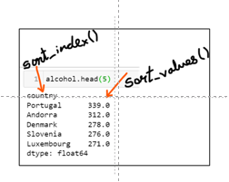

### Skill Challenge

Select all the countries from alcohol that have more than 50 wine servings , and save them (and the coresponding values) in a variable fifty_plus

```python
fifty_plus = alcohol[alcohol > 50]
```

```python
fifty_plus.head()
```

```
country
Portugal      339.0
Andorra       312.0
Denmark       278.0
Slovenia      276.0
Luxembourg    271.0
dtype: float64
```

```python
fifty_plus.count()
```

```
48
```

**Observation**

- We got 48 such countries

#### From fifty_plus, choose the countries with the smallest 20 wine servings values.

```python
fifty_plus.nsmallest(n = 20)
```

```
country
Seychelles             51.0
Bahamas                51.0
Albania                54.0
Lithuania              56.0
Poland                 56.0
Estonia                59.0
Gabon                  59.0
Latvia                 62.0
St. Lucia              71.0
Russian Federation     73.0
Paraguay               74.0
Cook Islands           74.0
Iceland                78.0
South Africa           81.0
USA                    84.0
Macedonia              86.0
Bulgaria               94.0
Finland                97.0
Spain                 112.0
Cyprus                113.0
dtype: float64
```

#### What is the MEAN , Median and Standard Deviation of the above sample?

```python
fifty_plus.nsmallest(n = 20).describe()
```

```
count     20.000000
mean      74.250000
std       19.072921
min       51.000000
25%       58.250000
50%       73.500000
75%       84.500000
max      113.000000
dtype: float64
```

### Series Arithmetics and fill_value()

#### We want to add 2 Servings to everyone's wine consumption

```python
alcohol+2
```

```
country
Portugal      341.0
Andorra       314.0
Denmark       280.0
Slovenia      278.0
Luxembourg    273.0
              ...
Sri Lanka       NaN
Sudan           NaN
Tajikistan      NaN
Uganda          NaN
Yemen           NaN
Length: 193, dtype: float64
```

```python
drinks['wine_servings']
```

```
0        NaN
1       54.0
2       14.0
3      312.0
4       45.0
       ...
188      3.0
189      1.0
190      NaN
191      4.0
192      4.0
Name: wine_servings, Length: 193, dtype: float64
```

```python
drinks['wine_servings'] + 2
```

```
0        NaN
1       56.0
2       16.0
3      314.0
4       47.0
       ...
188      5.0
189      3.0
190      NaN
191      6.0
192      6.0
Name: wine_servings, Length: 193, dtype: float64
```

```python
(alcohol - 10) * 2
```

```
country
Portugal      658.0
Andorra       604.0
Denmark       536.0
Slovenia      532.0
Luxembourg    522.0
              ...
Sri Lanka       NaN
Sudan           NaN
Tajikistan      NaN
Uganda          NaN
Yemen           NaN
Length: 193, dtype: float64
```

One of the greatest features of Pandas Data structures is that the Indices align automatically

```python
alcohol.head()
```

```
country
Portugal      339.0
Andorra       312.0
Denmark       278.0
Slovenia      276.0
Luxembourg    271.0
dtype: float64
```

```python
alcohol.sort_index(inplace = True)
```

```python
alcohol
```

```
country
Afghanistan      NaN
Albania         54.0
Algeria         14.0
Andorra        312.0
Angola          45.0
               ...
Venezuela        3.0
Vietnam          1.0
Yemen            NaN
Zambia           4.0
Zimbabwe         4.0
Length: 193, dtype: float64
```

```python
#Creating a Series
more_drinks = pd.Series({'Albania' : 6})
```

```python
more_drinks
```

```
Albania    6
dtype: int64
```

```python
#We will add more_drinks to alcohol series

alcohol + more_drinks
```

```
Afghanistan     NaN
Albania        60.0
Algeria         NaN
Andorra         NaN
Angola          NaN
               ...
Venezuela       NaN
Vietnam         NaN
Yemen           NaN
Zambia          NaN
Zimbabwe        NaN
Length: 193, dtype: float64
```

By why have all other values turned NAN ?

Both alcohol and more_drinks have the country "Albania" so that got populated

```python
#Lets add one more country and check
more_drinks = pd.Series({'Albania' : 6 , 'Algeria' : 10})
```

```python
alcohol + more_drinks
```

```
Afghanistan     NaN
Albania        60.0
Algeria        24.0
Andorra         NaN
Angola          NaN
               ...
Venezuela       NaN
Vietnam         NaN
Yemen           NaN
Zambia          NaN
Zimbabwe        NaN
Length: 193, dtype: float64
```

#### But , to avoid other values from becoming NAN

- Instead of using "+" operator , we can say :

```python
alcohol.head(5)
```

```
country
Afghanistan      NaN
Albania         54.0
Algeria         14.0
Andorra        312.0
Angola          45.0
dtype: float64
```

```python
alcohol.add(more_drinks)
```

```
Afghanistan     NaN
Albania        60.0
Algeria        24.0
Andorra         NaN
Angola          NaN
               ...
Venezuela       NaN
Vietnam         NaN
Yemen           NaN
Zambia          NaN
Zimbabwe        NaN
Length: 193, dtype: float64
```

```python
alcohol.add(more_drinks , fill_value = 0)
```

```
Afghanistan      NaN
Albania         60.0
Algeria         24.0
Andorra        312.0
Angola          45.0
               ...
Venezuela        3.0
Vietnam          1.0
Yemen            NaN
Zambia           4.0
Zimbabwe         4.0
Length: 193, dtype: float64
```

```python
more_drinks = pd.Series({'AAA' : 6 })
```

```python
alcohol.add(more_drinks , fill_value = 0)
```

```
AAA              6.0
Afghanistan      NaN
Albania         54.0
Algeria         14.0
Andorra        312.0
               ...
Venezuela        3.0
Vietnam          1.0
Yemen            NaN
Zambia           4.0
Zimbabwe         4.0
Length: 194, dtype: float64
```

```python
drinks['wine_servings'].head(3)
```

```
0     NaN
1    54.0
2    14.0
Name: wine_servings, dtype: float64
```

```python
test = pd.Series([13])
```

```python
drinks['wine_servings'].add(test , fill_value =0)
```

```
0       13.0
1       54.0
2       14.0
3      312.0
4       45.0
       ...
188      3.0
189      1.0
190      NaN
191      4.0
192      4.0
Length: 193, dtype: float64
```

```python
#Lets add one more country and check
more_drinks = pd.Series({'Albania' : 6 , 'Algeria' : 10})
```

```python
alcohol
```

```
country
Afghanistan      NaN
Albania         54.0
Algeria         14.0
Andorra        312.0
Angola          45.0
               ...
Venezuela        3.0
Vietnam          1.0
Yemen            NaN
Zambia           4.0
Zimbabwe         4.0
Length: 193, dtype: float64
```

```python
alcohol.add(more_drinks)
```

```
Afghanistan     NaN
Albania        60.0
Algeria        24.0
Andorra         NaN
Angola          NaN
               ...
Venezuela       NaN
Vietnam         NaN
Yemen           NaN
Zambia          NaN
Zimbabwe        NaN
Length: 193, dtype: float64
```

```python
alcohol.add(more_drinks , fill_value =0)
```

```
Afghanistan      NaN
Albania         60.0
Algeria         24.0
Andorra        312.0
Angola          45.0
               ...
Venezuela        3.0
Vietnam          1.0
Yemen            NaN
Zambia           4.0
Zimbabwe         4.0
Length: 193, dtype: float64
```

When we use "fill_value" we make sure not to lose data.

#### Be careful while using "fill_value" , if you use any other number other than 0 , it will add up to the existing values.

```python
alcohol.add(more_drinks , fill_value =40000)
```

```
Afghanistan        NaN
Albania           60.0
Algeria           24.0
Andorra        40312.0
Angola         40045.0
                ...
Venezuela      40003.0
Vietnam        40001.0
Yemen              NaN
Zambia         40004.0
Zimbabwe       40004.0
Length: 193, dtype: float64
```

```python
alcohol.add(more_drinks , fill_value =-0.001)
```

```
Afghanistan        NaN
Albania         60.000
Algeria         24.000
Andorra        311.999
Angola          44.999
                ...
Venezuela        2.999
Vietnam          0.999
Yemen              NaN
Zambia           3.999
Zimbabwe         3.999
Length: 193, dtype: float64
```

### .subtract()

```python
#Lets add one more country and check
more_drinks = pd.Series({'Andorra' : 312.0 , 'Angola' : 45.0})
```

```python
alcohol
```

```
country
Afghanistan      NaN
Albania         54.0
Algeria         14.0
Andorra        312.0
Angola          45.0
               ...
Venezuela        3.0
Vietnam          1.0
Yemen            NaN
Zambia           4.0
Zimbabwe         4.0
Length: 193, dtype: float64
```

```python
alcohol.subtract(more_drinks , fill_value = 0)
```

```
Afghanistan     NaN
Albania        54.0
Algeria        14.0
Andorra         0.0
Angola          0.0
               ...
Venezuela       3.0
Vietnam         1.0
Yemen           NaN
Zambia          4.0
Zimbabwe        4.0
Length: 193, dtype: float64
```

```python
#Lets add one more country and check
more_drinks = pd.Series({'Andorra' : 0 , 'Angola' : 0})
```

```python
alcohol.subtract(more_drinks , fill_value = 1)
```

```
Afghanistan      NaN
Albania         53.0
Algeria         13.0
Andorra        312.0
Angola          45.0
               ...
Venezuela        2.0
Vietnam          0.0
Yemen            NaN
Zambia           3.0
Zimbabwe         3.0
Length: 193, dtype: float64
```

```python
alcohol -1
```

```
country
Afghanistan      NaN
Albania         53.0
Algeria         13.0
Andorra        311.0
Angola          44.0
               ...
Venezuela        2.0
Vietnam          0.0
Yemen            NaN
Zambia           3.0
Zimbabwe         3.0
Length: 193, dtype: float64
```

```python
#divide
more_drinks = pd.Series({'Albania' : 6 , 'Algeria' : 10})
```

```python
alcohol.divide(more_drinks , fill_value = 1)
```

```
Afghanistan      NaN
Albania          9.0
Algeria          1.4
Andorra        312.0
Angola          45.0
               ...
Venezuela        3.0
Vietnam          1.0
Yemen            NaN
Zambia           4.0
Zimbabwe         4.0
Length: 193, dtype: float64
```

```python
alcohol
```

```
country
Afghanistan      NaN
Albania         54.0
Algeria         14.0
Andorra        312.0
Angola          45.0
               ...
Venezuela        3.0
Vietnam          1.0
Yemen            NaN
Zambia           4.0
Zimbabwe         4.0
Length: 193, dtype: float64
```

```python
alcohol.multiply(more_drinks , fill_value = 1)
```

```
Afghanistan      NaN
Albania        324.0
Algeria        140.0
Andorra        312.0
Angola          45.0
               ...
Venezuela        3.0
Vietnam          1.0
Yemen            NaN
Zambia           4.0
Zimbabwe         4.0
Length: 193, dtype: float64
```

### BONUS : Calculating Variance and Std Deviation

Variance is a measure of variability in statistics. It assesses the average squared difference between data values and the mean. Unlike some other statistical measures of variability, it incorporates all data points in its calculations by contrasting each value to the mean.

https://statisticsbyjim.com/basics/variance/

When there is no variability in a sample, all values are the same, and the variance equals zero. As the data values spread out further, variability increases.

For example, these two distributions have the same mean. However, the dataset on the right has greater variability and, hence, a higher variance.

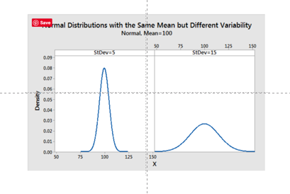

To Calculate the Variance manually:

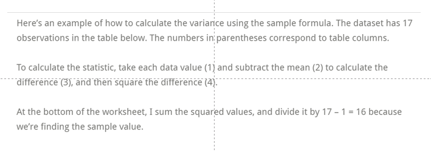

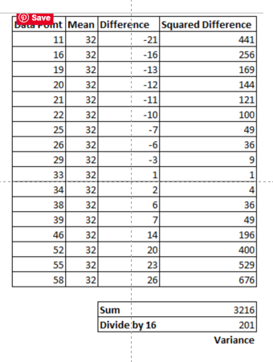

Interpreting the Variance The variance in statistics is the average squared distance between the data points and the mean. Because it uses squared units rather than the natural data units, the interpretation is less intuitive. Higher values indicate greater variability, but there is no intuitive interpretation for specific values. Despite this drawback, some statistical hypothesis tests use it in their calculations. For example, read about the F-test and ANOVA.

Squaring the differences serves several purposes.

Squaring the differences prevents values above and below the mean from canceling each other out. Consequently, variance is always greater than or equal to zero. It is almost always a positive value because only datasets containing one repeated value (e.g., all values equal 15) have a value of zero.

If you take the square root of the variance, you obtain the standard deviation, which does use the intuitive natural data units.

The standard deviation (SD) is a single number that summarizes the variability in a dataset. It represents the typical distance between each data point and the mean. Smaller values indicate that the data points cluster closer to the mean—the values in the dataset are relatively consistent. Conversely, higher values signify that the values spread out further from the mean. Data values become more dissimilar, and extreme values become more likely.

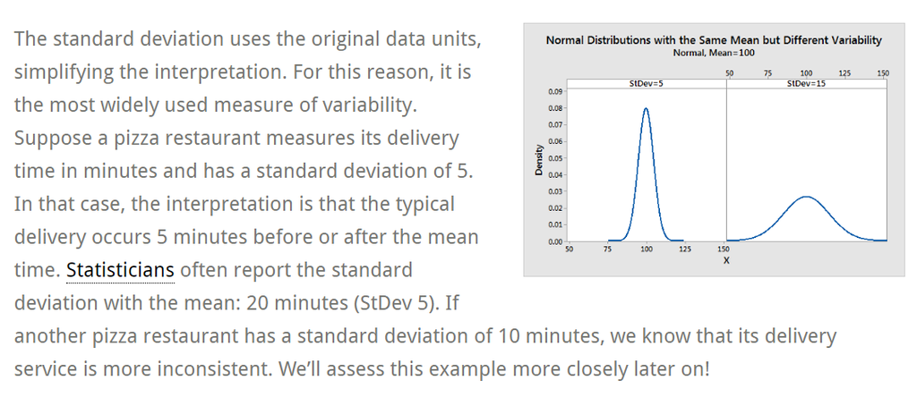

Understanding the standard deviation is crucial. While the mean identifies a central value in the distribution, it does not indicate how far the data points fall from the center. Higher SD values signify that more data points are further away from the mean. In other words, extreme values occur more frequently.

Variability is everywhere. When you order a favorite meal at a restaurant, it isn’t exactly the same each time. Your drive time to work varies every day. Parts from an assembly line might seem identical, but they have subtly different lengths and widths.

When variability is high, you can expect to experience extreme values more frequently, which can cause problems! If the restaurant meal differs noticeably from the usual, you might not like it at all. When your morning commute takes much longer than the average travel time, you will be late. And, manufactured parts that are too far out of spec won’t perform correctly.

https://statisticsbyjim.com/basics/standard-deviation/

Example of Using the Standard Deviation Suppose two pizza restaurants advertise a 20-minute average delivery time. We’re starving and both look equally good! However, we know the mean does not tell the entire story!

Let’s assess their standard deviations to choose the restaurant. Imagine we obtain their delivery time data. One restaurant has a SD of 10 minutes while the other has a value of 5. How does this affect deliveries?

The graphs below incorporate the SDs to answer this question. The restaurant with the larger standard deviation (10 minutes) has more variable delivery times and a broader distribution curve.

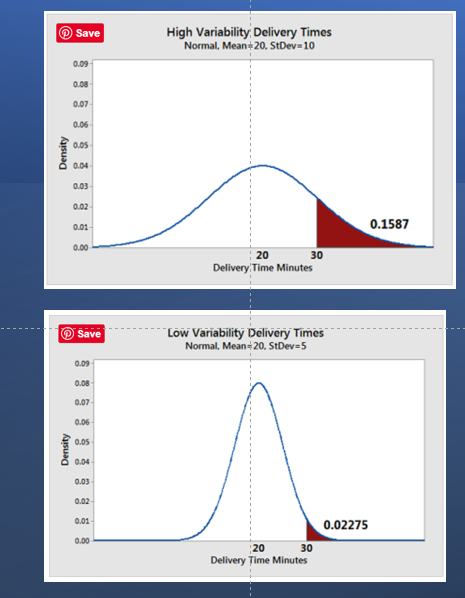

In these charts, we’ll consider a 30-minute wait or longer to be unacceptable—we’re hungry! The shaded areas represent the percentage of delivery times exceeding 30 minutes. Almost 16% of deliveries for the high variability pizza joint exceed 30 minutes compared to only 2% for the low variability restaurant. They both have a mean delivery time of 20 minutes, but I know where I’d place my order when I’m hungry!

I always recommend graphing your data in a histogram so you can see the variability. These charts really bring the SD to life!

How to Calculate Std Deviation:

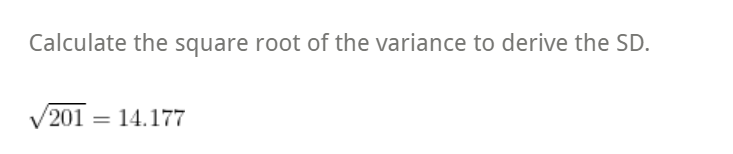

Back to Bootcamp lecture:

https://www.udemy.com/course/the-ultimate-pandas-bootcamp-advanced-python-data-analysis/learn/lecture/18297906#overview

```python
alcohol.var()
```

```
5796.52561153286
```

Variance is simply the Average of Squared differences from the MEAN

For each observation, find its difference relative to the MEAN , then Square that difference and then find the SUM of all those differences for each observation. Then in the end divide the Sum of these Squared differences by "n" which is the "Number of Observations in the sample" MINUS 1 (n-1). this "-1" here is known as the Degrees of Freedom adjustment.

This is to say that there is only "n-1" degrees of Freedom in our sample. Which is to say that not all the observations in our sample have the Freedom to vary. Because the SUM of the Difference between each observation and the MEAN should equal to ZERO

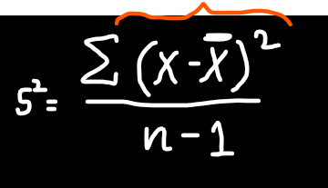

So, if we know the Average and all the values except one of them, we could figure that one value our based on this fact alone and thats the reason why we divide by "n-1" here instead of n

Hence , this way the sample variance is adjusted for the right Degrees of Freedom , that is "n-1"

And finally the Sample Std Deviation is the Square Root of the Variance.

```python
#Variance
alcohol.var()
```

```
5796.52561153286
```

```python
#Lets try to replicate this with the Std Dev formula
#We are subtracting the MEAN from each and every value in the alcohol series
#And we Square it

alcohol.subtract(alcohol.mean())**2
```

```
country
Afghanistan             NaN
Albania           10.582571
Algeria         1350.335658
Andorra        68253.175164
Angola            33.027016
                   ...
Venezuela       2279.767756
Vietnam         2474.755411
Yemen                   NaN
Zambia          2185.273929
Zimbabwe        2185.273929
Length: 193, dtype: float64
```

```python
#And Finally we have to calculate the SUM of above
#At this point we are looking at the sum of Squared differences
(alcohol.subtract(alcohol.mean())**2).sum()
```

```
933240.6234567901
```

```python
#Finally we have to divide by n-1
#n is the number of observations
#Which is alcohol.count()
#n = alcohol.count()
(alcohol.subtract(alcohol.mean())**2).sum() / (alcohol.count()-1)
```

```
5796.5256115328575
```

```python
#Lets look at the direct Std formula

alcohol.std()
```

```
76.13491716376173
```

```python
#If we take the half of this then we get the same thing
((alcohol.subtract(alcohol.mean())**2).sum() / (alcohol.count()-1))**(1/2)
```

```
76.13491716376171
```

### Cumulative Operations

```python
#we are already familiar with the sum function

alcohol.sum()
```

```
8221.0
```

```python
#cumsum calculates the Cumulative sum
#We calculate the progressive or Cumulative sum
alcohol.cumsum()
```

```
country
Afghanistan       NaN
Albania          54.0
Algeria          68.0
Andorra         380.0
Angola          425.0
                ...
Venezuela      8212.0
Vietnam        8213.0
Yemen             NaN
Zambia         8217.0
Zimbabwe       8221.0
Length: 193, dtype: float64
```

**Observation**

- Each value in the Series is the cumulative sum of the value preceding it
- And the last one is going to be the sum of the entire Series
- NAs are skipped by default

Note : Whenever we try to operate on NA , we end up getting NA

```python
np.NAN + 1234566777
```

```
nan
```

```python
type(np.NAN)
```

```
float
```

```python
#Pandas also has its own NA
pd.NA + 124456678
```

```
<NA>
```

```python
type(pd.NA)
```

```
pandas._libs.missing.NAType
```

```python
#We can calculate the Product of all servings using the prod() method

alcohol.prod()
```

```
3.4276115052182805e+183
```

```python
#This product accumulates using cumprod
alcohol.cumprod()
```

```
country
Afghanistan              NaN
Albania         5.400000e+01
Algeria         7.560000e+02
Andorra         2.358720e+05
Angola          1.061424e+07
                   ...
Venezuela      2.142257e+182
Vietnam        2.142257e+182
Yemen                    NaN
Zambia         8.569029e+182
Zimbabwe       3.427612e+183
Length: 193, dtype: float64
```

```python
alcohol.cumprod()[-1] == alcohol.prod()
```

```
True
```

```python
#Cummin and cummax
```

```python
alcohol.min()
```

```
1.0
```

```python
alcohol.cummin()
```

```
country
Afghanistan     NaN
Albania        54.0
Algeria        14.0
Andorra        14.0
Angola         14.0
               ...
Venezuela       1.0
Vietnam         1.0
Yemen           NaN
Zambia          1.0
Zimbabwe        1.0
Length: 193, dtype: float64
```

```python
alcohol.cummax()
```

```
country
Afghanistan      NaN
Albania         54.0
Algeria         54.0
Andorra        312.0
Angola         312.0
               ...
Venezuela      339.0
Vietnam        339.0
Yemen            NaN
Zambia         339.0
Zimbabwe       339.0
Length: 193, dtype: float64
```

### Pairwise differences with diff()

diff() method is very useful in Data Science, specially when working with TimeSeries.

diff() is used to calculate the Discrete difference for pairs of elements in a Series. So there will be a difference between one element and another

```python
alcohol.diff().head()
```

```
country
Afghanistan      NaN
Albania          NaN
Algeria        -40.0
Andorra        298.0
Angola        -267.0
dtype: float64
```

```python
drinks['wine_servings'].diff().head()
```

```
0      NaN
1      NaN
2    -40.0
3    298.0
4   -267.0
Name: wine_servings, dtype: float64
```

[figure not shown]

```python
alcohol
```

```
country
Afghanistan      NaN
Albania         54.0
Algeria         14.0
Andorra        312.0
Angola          45.0
               ...
Venezuela        3.0
Vietnam          1.0
Yemen            NaN
Zambia           4.0
Zimbabwe         4.0
Length: 193, dtype: float64
```

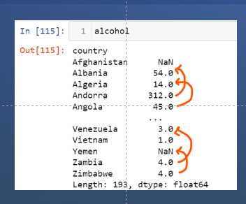

```python
#We can adjust the "periods" parameter to get the diff of previous - previous country (meaning 2 step up)
alcohol.diff(periods = 2).head(10)
```

```
country
Afghanistan            NaN
Albania                NaN
Algeria                NaN
Andorra              258.0
Angola                31.0
Antigua & Barbuda   -267.0
Argentina            176.0
Armenia              -34.0
Australia             -9.0
Austria              180.0
dtype: float64
```

```python
alcohol.diff(periods = 2).tail(5)
```

```
country
Venezuela    -5.0
Vietnam     -10.0
Yemen         NaN
Zambia        3.0
Zimbabwe      NaN
dtype: float64
```

Well , in this series , this diff method does not have a whole lot of meaning yet.

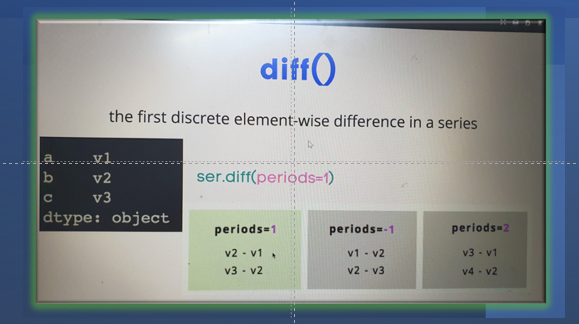

```python
#periods = -1 wll calculate the diff in reverse order
```

### Series Iteration

When we want to iterate over each element in a Series.

- Lets start with the basic Python for loop

```python
#Creating a slice of first 10 elements of alcohol series
mini_alc = alcohol[:10]
```

```python
mini_alc
```

```
country
Afghanistan            NaN
Albania               54.0
Algeria               14.0
Andorra              312.0
Angola                45.0
Antigua & Barbuda     45.0
Argentina            221.0
Armenia               11.0
Australia            212.0
Austria              191.0
dtype: float64
```

```python
for i in mini_alc:
    print(i)
```

```
nan
54.0
14.0
312.0
45.0
45.0
221.0
11.0
212.0
191.0
```

```python
#We want to iterate over the Index labels

for i in mini_alc.index:
    print(i)
```

```
Afghanistan
Albania
Algeria
Andorra
Angola
Antigua & Barbuda
Argentina
Armenia
Australia
Austria
```

https://www.udemy.com/course/the-ultimate-pandas-bootcamp-advanced-python-data-analysis/learn/lecture/18328310#overview

```python
drinks = pd.read_csv('drinks.csv')
```

```python
#Creating the Series again
#Creating alcohol Series with "country" as index and values of wine_servings
alcohol = pd.Series(drinks['wine_servings'].values, index=drinks['country'])
```

```python
type(alcohol)
```

```
pandas.core.series.Series
```

```python
#Creating a slice of first 10 elements of alcohol series
mini_alc = alcohol[:10]
```

```python
#We want to iterate over the Index Labels
for i in mini_alc.index:
    print(i)
```

```
Afghanistan
Albania
Algeria
Andorra
Angola
Antigua & Barbuda
Argentina
Armenia
Australia
Austria
```

```python
drinks.columns
```

```
Index(['country', 'beer_servings', 'spirit_servings', 'wine_servings',
       'total_litres_of_pure_alcohol'],
      dtype='object')
```

```python
#We access the indexes as well as the values associated with that
for i in drinks.index:
    print(i , drinks.wine_servings[i] )
```

```
0 nan
1 54.0
2 14.0
3 312.0
4 45.0
5 45.0
6 221.0
7 11.0
8 212.0
9 191.0
10 5.0
11 51.0
12 7.0
13 nan
14 36.0
```

[output cut: 178 more lines]

```python
#We access the indexes as well as the values associated with that
for i in mini_alc.index:
    print(i , mini_alc[i])
```

```
Afghanistan nan
Albania 54.0
Algeria 14.0
Andorra 312.0
Angola 45.0
Antigua & Barbuda 45.0
Argentina 221.0
Armenia 11.0
Australia 212.0
Austria 191.0
```

### items()

```python
#Pandas also provides a much more convenient alternative and that is the items method
#Notice here we are getting tuples as output
#The items method returns a lazily evaluated iterable of tuples
#Meaning : Its only evaluated when we ask it
#behind the scene it uses the zip() method
for i in mini_alc.items():
    print(i)
```

```
('Afghanistan', nan)
('Albania', 54.0)
('Algeria', 14.0)
('Andorra', 312.0)
('Angola', 45.0)
('Antigua & Barbuda', 45.0)
('Argentina', 221.0)
('Armenia', 11.0)
('Australia', 212.0)
('Austria', 191.0)
```

### iteritems()

```python
#items() and iteritems() are completely idenstical
for i in mini_alc.iteritems():
    print(i)
```

```
('Afghanistan', nan)
('Albania', 54.0)
('Algeria', 14.0)
('Andorra', 312.0)
('Angola', 45.0)
('Antigua & Barbuda', 45.0)
('Argentina', 221.0)
('Armenia', 11.0)
('Australia', 212.0)
('Austria', 191.0)
```

### Filtering : filter() , where() , mask()

```python
#We only want to look at countries that start with "v"
#We can use the Series filter() method to find out
#using with a regex parameter here
#We are filtering our Series by specifying a string pattern
#We are filtering along the index labels and not the values (very important)
alcohol.filter(regex = '^V')
```

```
country
Vanuatu      11.0
Venezuela     3.0
Vietnam       1.0
dtype: float64
```

```python
#We can use the "like" parameter with filter()
#This is also applied to the index and not the values
alcohol.filter(like = 'stan')
```

```
country
Afghanistan      NaN
Kazakhstan      12.0
Kyrgyzstan       6.0
Pakistan         NaN
Tajikistan       NaN
Turkmenistan    32.0
Uzbekistan       8.0
dtype: float64
```

### What if we want to filter by values instead?

```python
#we can simply use the Square brackets indexing
```

```python
drinks[drinks['country'].str.contains('stan')]
```

|  | country | beer_servings | spirit_servings | wine_servings | total_litres_of_pure_alcohol |
| --- | --- | --- | --- | --- | --- |
| 0 | Afghanistan | NaN | NaN | NaN | NaN |
| 87 | Kazakhstan | 124.0 | 246.0 | 12.0 | 6.8 |
| 91 | Kyrgyzstan | 31.0 | 97.0 | 6.0 | 2.4 |
| 128 | Pakistan | NaN | NaN | NaN | NaN |
| 168 | Tajikistan | 2.0 | 15.0 | NaN | 0.3 |
| 177 | Turkmenistan | 19.0 | 71.0 | 32.0 | 2.2 |
| 186 | Uzbekistan | 25.0 | 11.0 | 8.0 | 2.4 |

```python
drinks[drinks['country'].str.startswith('V')]
```

|  | country | beer_servings | spirit_servings | wine_servings | total_litres_of_pure_alcohol |
| --- | --- | --- | --- | --- | --- |
| 187 | Vanuatu | 21.0 | 18.0 | 11.0 | 0.9 |
| 188 | Venezuela | 333.0 | 1.0 | 3.0 | 7.7 |
| 189 | Vietnam | 111.0 | 2.0 | 1.0 | 2.0 |

```python
#wine servings greater than 200
alcohol[alcohol > 200]
```

```
country
Andorra              312.0
Argentina            221.0
Australia            212.0
Belgium              212.0
Croatia              254.0
Denmark              278.0
Equatorial Guinea    233.0
Greece               218.0
Italy                237.0
Luxembourg           271.0
Portugal             339.0
Slovenia             276.0
dtype: float64
```

```python
#wine servings greater than 200
#using loc indexer
alcohol[alcohol > 200]
```

```
country
Andorra              312.0
Argentina            221.0
Australia            212.0
Belgium              212.0
Croatia              254.0
Denmark              278.0
Equatorial Guinea    233.0
Greece               218.0
Italy                237.0
Luxembourg           271.0
Portugal             339.0
Slovenia             276.0
dtype: float64
```

### Define a function to apply filter

- We are creating a function , a callable > "def gt200(x)"
- And then we are passing a reference to that callable to the square bracket indexing > "alcohol[gt200]"
- The Series itself is passed to the 'x' parameter of the function

```python
def gt200(x):
    return x > 200
```

```python
#Calling the function on Series
alcohol[gt200]
```

```
country
Andorra              312.0
Argentina            221.0
Australia            212.0
Belgium              212.0
Croatia              254.0
Denmark              278.0
Equatorial Guinea    233.0
Greece               218.0
Italy                237.0
Luxembourg           271.0
Portugal             339.0
Slovenia             276.0
dtype: float64
```

```python
#Calling the function on DataFrame > Column
drinks.wine_servings[gt200]
```

```
3      312.0
6      221.0
8      212.0
16     212.0
42     254.0
48     278.0
55     233.0
67     218.0
83     237.0
99     271.0
136    339.0
156    276.0
Name: wine_servings, dtype: float64
```

### where() method

The where() method is not truly meant for filtering

- This is a method which allows us to efficiently replace values where the given condition is False
- This is how it works:
- alcohol.where("Condition", "value to be replaced for x if condition is False")

```python
alcohol.where(lambda x: x>200 , other = 'too small')
```

```
country
Afghanistan    too small
Albania        too small
Algeria        too small
Andorra              312
Angola         too small
                 ...
Venezuela      too small
Vietnam        too small
Yemen          too small
Zambia         too small
Zimbabwe       too small
Length: 193, dtype: object
```

```python
#if we get rid of this "other" parameter
#Pandas will replace the values where condition is False with NAN
#This is because , the default value for other is NAN
alcohol.where(lambda x: x>200 )
```

```
country
Afghanistan      NaN
Albania          NaN
Algeria          NaN
Andorra        312.0
Angola           NaN
               ...
Venezuela        NaN
Vietnam          NaN
Yemen            NaN
Zambia           NaN
Zimbabwe         NaN
Length: 193, dtype: float64
```

#### Combination of where() with dropna()

```python
#Now if we use the dropna() method, we will be left with only the values which satisfy the condition
alcohol.where(lambda x: x>200 ).dropna()
```

```
country
Andorra              312.0
Argentina            221.0
Australia            212.0
Belgium              212.0
Croatia              254.0
Denmark              278.0
Equatorial Guinea    233.0
Greece               218.0
Italy                237.0
Luxembourg           271.0
Portugal             339.0
Slovenia             276.0
dtype: float64
```

#### Filtering values where the Condition is False

### mask()

- where() replaces where the condition is False
- mask() replaces where the condition is True

```python
alcohol.mask(lambda x : x > 200).dropna()
```

```
country
Albania              54.0
Algeria              14.0
Angola               45.0
Antigua & Barbuda    45.0
Armenia              11.0
                     ...
Vanuatu              11.0
Venezuela             3.0
Vietnam               1.0
Zambia                4.0
Zimbabwe              4.0
Length: 150, dtype: float64
```

**Observation**

- We get all the countries where this condition was not true

### Transforming with update() apply() and map()

```python
alcohol.head(10)
```

```
country
Afghanistan            NaN
Albania               54.0
Algeria               14.0
Andorra              312.0
Angola                45.0
Antigua & Barbuda     45.0
Argentina            221.0
Armenia               11.0
Australia            212.0
Austria              191.0
dtype: float64
```

```python
#Lets say we want to assign a nnew value to 'Algeria'
alcohol.loc['Algeria'] = 19
```

```python
alcohol.head(10)
```

```
country
Afghanistan            NaN
Albania               54.0
Algeria               19.0
Andorra              312.0
Angola                45.0
Antigua & Barbuda     45.0
Argentina            221.0
Armenia               11.0
Australia            212.0
Austria              191.0
dtype: float64
```

```python
drinks.loc[0 , 'wine_servings'] = 19
```

```python
drinks.head(2)
```

|  | country | beer_servings | spirit_servings | wine_servings | total_litres_of_pure_alcohol |
| --- | --- | --- | --- | --- | --- |
| 0 | Afghanistan | NaN | NaN | 19.0 | NaN |
| 1 | Albania | 89.0 | 132.0 | 54.0 | 4.9 |

#### what if we want to modify multiple records

### update() method

```python
#It becomes very repetitive
#For such cases , we have the update method which modifies the Series in-place using the Non-NA values from
#another series
```

```python
alcohol.update(pd.Series(data = [200 , 20], index = ['Albania' , 'Algeria']))
```

```python
alcohol.head()
```

```
country
Afghanistan     19.0
Albania        200.0
Algeria         20.0
Andorra        312.0
Angola          45.0
dtype: float64
```

```python
drinks['wine_servings'].update(pd.Series(data = [205 , 205], index = [1 , 2]))
```

```python
drinks['wine_servings'].head()
```

```
0     19.0
1    205.0
2    205.0
3    312.0
4     45.0
Name: wine_servings, dtype: float64
```

```python
drinks.head()
```

|  | country | beer_servings | spirit_servings | wine_servings | total_litres_of_pure_alcohol |
| --- | --- | --- | --- | --- | --- |
| 0 | Afghanistan | NaN | NaN | 19.0 | NaN |
| 1 | Albania | 89.0 | 132.0 | 205.0 | 4.9 |
| 2 | Algeria | 25.0 | NaN | 205.0 | 0.7 |
| 3 | Andorra | 245.0 | 138.0 | 312.0 | 12.4 |
| 4 | Angola | 217.0 | 57.0 | 45.0 | 5.9 |

### What if we plan to apply a common transformation to all the elements in our series

### or to the whole column in the Dataframe

### apply() method

apply() method applies transformation to each and every element in a Series

```python
#What is a transformation?
#It could be literally any function
#could be a basic Lambda function
#Or an anonymous function
```

```python
alcohol.apply(lambda x: x**2)
```

```
country
Afghanistan      361.0
Albania        42025.0
Algeria        42025.0
Andorra        97344.0
Angola          2025.0
                ...
Venezuela          9.0
Vietnam            1.0
Yemen              NaN
Zambia            16.0
Zimbabwe          16.0
Length: 193, dtype: float64
```

**Observation**

- We have a new series where each wine serving has been Squared

```python
#Another way to do this , is use the Numpy Universal function
```

```python
alcohol.apply(np.square)
```

```
country
Afghanistan      361.0
Albania        42025.0
Algeria        42025.0
Andorra        97344.0
Angola          2025.0
                ...
Venezuela          9.0
Vietnam            1.0
Yemen              NaN
Zambia            16.0
Zimbabwe          16.0
Length: 193, dtype: float64
```

```python
#Define our own function
```

```python
def multiply_by_self(x):
    return x*x
```

```python
alcohol.apply(multiply_by_self)
```

```
country
Afghanistan      361.0
Albania        42025.0
Algeria        42025.0
Andorra        97344.0
Angola          2025.0
                ...
Venezuela          9.0
Vietnam            1.0
Yemen              NaN
Zambia            16.0
Zimbabwe          16.0
Length: 193, dtype: float64
```

```python
#Lets say we want to square only those wine servings that are below a minimum amount
#We define a function to square only those wine servings that are below a minimum amount
#otherwise simply return x unchanged if condition is false
```

```python
#We want the function to go to each value in the Series
#compare each value to the min_servings which is yet to be specified
#return the Square of x if x is below min_servings
#Otherwise return x unchanged
```

This is a Multi-Parameter function

- We use positional argument here

```python
def multiply_by_self_with_min(x, min_servings):
    if x < min_servings:
        return x*x

    return x
```

```python
alcohol.apply(multiply_by_self_with_min , args = (200,))
```

```
country
Afghanistan     361.0
Albania         205.0
Algeria         205.0
Andorra         312.0
Angola         2025.0
                ...
Venezuela         9.0
Vietnam           1.0
Yemen             NaN
Zambia           16.0
Zimbabwe         16.0
Length: 193, dtype: float64
```

This is a Multi-Parameter function

- We use keyword argument here
- We are specifying the parameter exactly by name

```python
alcohol.apply(multiply_by_self_with_min ,min_servings = 200 )
```

```
country
Afghanistan     361.0
Albania         205.0
Algeria         205.0
Andorra         312.0
Angola         2025.0
                ...
Venezuela         9.0
Vietnam           1.0
Yemen             NaN
Zambia           16.0
Zimbabwe         16.0
Length: 193, dtype: float64
```

https://www.udemy.com/course/the-ultimate-pandas-bootcamp-advanced-python-data-analysis/learn/lecture/18339366#overview

```python
drinks = pd.read_csv('drinks.csv')
```

```python
#Creating the Series again
#Creating alcohol Series with "country" as index and values of wine_servings
alcohol = pd.Series(drinks['wine_servings'].values, index=drinks['country'])
```

```python
alcohol
```

```
country
Afghanistan      NaN
Albania         54.0
Algeria         14.0
Andorra        312.0
Angola          45.0
               ...
Venezuela        3.0
Vietnam          1.0
Yemen            NaN
Zambia           4.0
Zimbabwe         4.0
Length: 193, dtype: float64
```

### the map() method

Althogh map() method is technically used for substituting values right. We can take control of the substitution.

the functionality of apply() and map() is identical.

```python
alcohol.map(lambda x:x**2)
```

```
country
Afghanistan        NaN
Albania         2916.0
Algeria          196.0
Andorra        97344.0
Angola          2025.0
                ...
Venezuela          9.0
Vietnam            1.0
Yemen              NaN
Zambia            16.0
Zimbabwe          16.0
Length: 193, dtype: float64
```

```python
alcohol.map(np.square)
```

```
country
Afghanistan        NaN
Albania         2916.0
Algeria          196.0
Andorra        97344.0
Angola          2025.0
                ...
Venezuela          9.0
Vietnam            1.0
Yemen              NaN
Zambia            16.0
Zimbabwe          16.0
Length: 193, dtype: float64
```

But , when we get into the more complex transformations , for example : Callables and Parameters, map and apply are no longer substitutes (you cannot use map() for complicated transformations)

#### Example : This code will work with apply() but not with map()

#### alcohol.map(multiply_by_self_with_min , args = (200, ))

If our transformation is very specific and very Custom , we would want to stick with apply()

### TRANSFORMS

#### We saw three methods to apply transformations

### update()

Modifies series values in place using another Series.

Syntax : Series.update(other_Series)

### apply()

Applies a function or a universal function (ufunc) or any custom function on each Series value .

apply() is most flexible

Example : Series.apply(np.sqrt)

### map()

map() is technically a substitution function that substitutes series values with other values from a function or Series or Dictionary.

map() is definitely more flsexible in terms of input

It accepts various types of inputs

But apply() is more flexible in terms of various transformations. We can define any function. We can control what inputs that function takes as we apply the function using positional or keyword arguments

apply() is a great choice if we want to apply the transformation to the entire series.

example : series.map({'old_value' : 'new_value'})

### Skill Challenge

Read the drinks.csv dataset, this time bringing the beer_servings sequence into a new Series, with country as the index, assign the Series to the variable "beers"

```python
drinks = pd.read_csv('drinks.csv')
```

```python
drinks.head(2)
```

|  | country | beer_servings | spirit_servings | wine_servings | total_litres_of_pure_alcohol |
| --- | --- | --- | --- | --- | --- |
| 0 | Afghanistan | NaN | NaN | NaN | NaN |
| 1 | Albania | 89.0 | 132.0 | 54.0 | 4.9 |

```python
#We can read just two columns from the csv
#drinks = pd.read_csv(data_url, usecols = ['country' , 'beer_servings
drinks = pd.read_csv('drinks.csv', usecols = ['country' , 'beer_servings'])
```

```python
#Creating the Series again
#Creating alcohol Series with "country" as index and values of wine_servings
beers = pd.Series(drinks['beer_servings'].values, index=drinks['country'])
```

#### OR

```python
#But remember this is still a dataframe
beers = pd.read_csv('drinks.csv' , usecols =['country' , 'beer_servings'] , index_col = 'country')
```

```python
type(beers)
```

```
pandas.core.frame.DataFrame
```

```python
#We were asked to convert the DataFrame to series
beers = pd.read_csv('drinks.csv' , usecols =['country' , 'beer_servings'] , index_col = 'country', squeeze = True)
```

```python
type(beers)
```

```
pandas.core.series.Series
```

```python
beers
```

```
country
Afghanistan      NaN
Albania         89.0
Algeria         25.0
Andorra        245.0
Angola         217.0
               ...
Venezuela      333.0
Vietnam        111.0
Yemen            6.0
Zambia          32.0
Zimbabwe        64.0
Name: beer_servings, Length: 193, dtype: float64
```

#### Calculate the Mean , Median and Standard Deviation of beer servings in beers. Is the Distribution Right or Left Skewed?

```python
beers.describe()
```

```
count    178.000000
mean     102.870787
std      100.645713
min        1.000000
25%       21.000000
50%       60.000000
75%      172.500000
max      376.000000
dtype: float64
```

If the Mean is greater than the Median than the Distribution is Right Skewed

If the Mean is lesser than the Median than the Distribution is Left Skewed

```python
beers.mean()
```

```
102.87078651685393
```

**Observation**

- We see 102.8 or 103 beer servings on a average in the Series

```python
beers.median()
```

```
60.0
```

```python
#We can find the median using the Quantile method
beers.quantile(0.5)
```

```
60.0
```

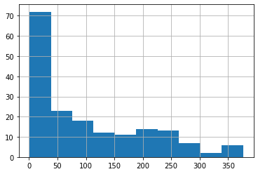

```python
beers.hist()
```

**Observation**

```python
beers.mean() > beers.median()
```

```
True
```

**Observation**

- The Distribution is Right skewed

#### Slice the first 10 countries from beers . Are they relatively large or small relative to the rest of the sample?

BONUS : To answer that we could compare each value to the mean or median. An even better approach would be to calculate standard scores or z-scores as they are known.

```python
#Slice first 10 countries from beer
beers[:10]
```

```
country
Afghanistan            NaN
Albania               89.0
Algeria               25.0
Andorra              245.0
Angola               217.0
Antigua & Barbuda     12.0
Argentina            193.0
Armenia               21.0
Australia            261.0
Austria              279.0
Name: beer_servings, dtype: float64
```

```python
#Are these large or small compared to rest of the sample
#One way to answer this is to look at the mean of the series
beers.mean()
```

```
102.87078651685393
```

```python
#We can subtract the mean from each of those observations
beers[ : 10] - beers.mean()
```

```
country
Afghanistan                 NaN
Albania              -13.870787
Algeria              -77.870787
Andorra              142.129213
Angola               114.129213
Antigua & Barbuda    -90.870787
Argentina             90.129213
Armenia              -81.870787
Australia            158.129213
Austria              176.129213
Name: beer_servings, dtype: float64
```

**Observations**

- We now get a Series of differences back
- The more significant the difference , the more further from the mean , the observation is.
- Positive differences indicate observations above the mean and Negative ones are below the mean.
- We can apply the function and convert the differences into labels for ease of understanding.

```python
(beers[ : 10] - beers.mean()).apply(lambda x : 'low' if x<0 else 'high')
```

```
country
Afghanistan          high
Albania               low
Algeria               low
Andorra              high
Angola               high
Antigua & Barbuda     low
Argentina            high
Armenia               low
Australia            high
Austria              high
Name: beer_servings, dtype: object
```

```python
#We can use value_counts to see where each value falls:
(beers[ : 10] - beers.mean()).apply(lambda x : 'low' if x<0 else 'high').value_counts()
```

```
high    6
low     4
Name: beer_servings, dtype: int64
```

```python
#If we look at the complete Series instead of the slice
(beers - beers.mean()).apply(lambda x : 'low' if x<0 else 'high').value_counts()
```

```
low     112
high     81
Name: beer_servings, dtype: int64
```

- We see that most observations are in the lower end , they are below the mean
- But a Significant component above the mean

There is some thing not clear about this approach . We really don't know how low or how high each observation is.

- A more standard approach to this would be to calculate the "Standard Score" or "Z-score" , In a way we are standardising each observation by quantifying it in terms of deviation from the mean.

### Z-Score

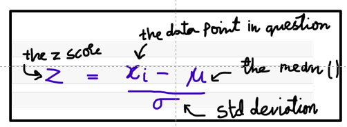

Z-Score is the number of Std Deviations that a given observation is being different from Sample MEAN

If the observation x is 10 and mean is 0 and we get a Z-score of 5 , we can say that the observation 10 is 5 std deviations away or above the mean of 0

```python
#We create a new series called "Z-scores"
#We start with observations Minus their beers.mean divided by the Std deviation

z_scores = (beers - beers.mean()) / beers.std()
```

```python
z_scores
```

```
country
Afghanistan         NaN
Albania       -0.137818
Algeria       -0.773712
Andorra        1.412174
Angola         1.133970
                 ...
Venezuela      2.286528
Vietnam        0.080771
Yemen         -0.962493
Zambia        -0.704161
Zimbabwe      -0.386214
Name: beer_servings, Length: 193, dtype: float64
```

```python
#Now if we look at head(10) , we will be looking at the first 10 observations
#How much away from the mean each observation is
z_scores.head(10)
```

```
country
Afghanistan               NaN
Albania             -0.137818
Algeria             -0.773712
Andorra              1.412174
Angola               1.133970
Antigua & Barbuda   -0.902878
Argentina            0.895510
Armenia             -0.813455
Australia            1.571147
Austria              1.749992
Name: beer_servings, dtype: float64
```

#### Which Country has the largest absolute Z-Score?

```python
z_scores.min()
```

```
-1.012172141315241
```

```python
z_scores.max()
```

```
2.7137689844109123
```

```python
z_scores.head(5)
```

```
country
Afghanistan         NaN
Albania       -0.137818
Algeria       -0.773712
Andorra        1.412174
Angola         1.133970
Name: beer_servings, dtype: float64
```

```python
#Better way would be to look at the abs Z-score of the entire series
#This creates a Series of only positive values
z_scores.abs().head(5)
```

```
country
Afghanistan         NaN
Albania        0.137818
Algeria        0.773712
Andorra        1.412174
Angola         1.133970
Name: beer_servings, dtype: float64
```

```python
#And then simply taking the
z_scores.abs().max()
```

```
2.7137689844109123
```

```python
beers.idxmax()
```

```
'Namibia'
```

```python
beers[beers.idxmax()]
```

```
376.0
```

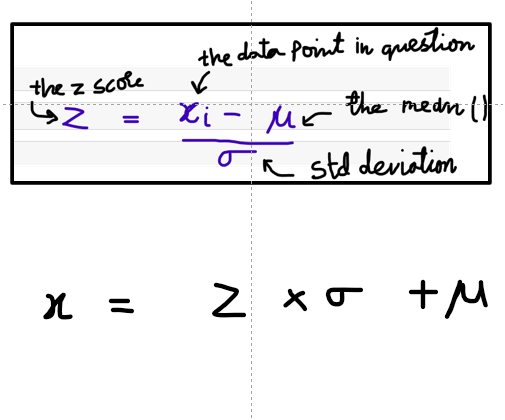

```python
#Lets look at the Z-score of this number
#If we do the below calculation , it should give us this number : 376.0

z_scores.abs().max() * beers.std() + beers.mean()
```

```
376.0
```

#### We canconclude the Namibia shows the maximum deviation from the MEAN

#### BONUS 4:

Create a new series that uses Series arithmetics to calculate the z-score for each serving, by subtracting from each , the MEAN and dividing the difference by the Standard Deviation. Point the variable z_scores to this Series.

Which country has the largest absolute z-score? Is this a positive or Negative Deviation?

```python
z_scores.abs().max() * beers.std() + beers.mean()
```

```
376.0
```

We can conclude the Namibia shows the maximum deviation from the MEAN

➖➖➖➖➖➖➖➖➖➖➖➖➖➖➖➖➖➖➖➖➖➖➖➖➖➖➖➖➖➖➖➖➖➖➖➖➖➖➖➖➖➖➖➖